# Effect of Power Plant Features on Their Electricity Generation.

## by Gladens Popoola

## Investigation Overview

> In this investigation, I want to find out what features affect electricity generation in 2017 as well as the features that influence estimated electricity generation in 2017. The focus was mainly on country, capacity_mw, primary_fuel, generation_gwh_2017, and estimated_generation_gwh_2017.

## Dataset Overview

> There are 34936 power plants in the dataset with 36 features(country, country_long, name, gppd_idnr, capacity_mw, latitude, longitude, primary_fuel, other_fuel1, other_fuel2, other_fuel3, commissioning_year, owner, source, url, geolocation_source, wepp_id, year_of_capacity_data, generation_gwh_2013, generation_gwh_2014, generation_gwh_2015, generation_gwh_2016, generation_gwh_2017, generation_gwh_2018, generation_gwh_2019, generation_data_source, estimated_generation_gwh_2013, estimated_generation_gwh_2014, estimated_generation_gwh_2015, estimated_generation_gwh_2016, estimated_generation_gwh_2017, estimated_generation_note_2013, estimated_generation_note_2014, estimated_generation_note_2015, estimated_generation_note_2016, estimated_generation_note_2017). For my analysis, I'll be focusing on the generation and estimated generation for the year 2017 alone so I'll be making use of the following columns: country_long, name, capacity_mw, primary_fuel, generation_gwh_2017, and estimated_generation_gwh_2017. So I created a new dataframe called power_plant_2017 containing these columns only. This dataframe contains 33007 power plants and 6 features(needed for my analysis). Of the 6 features, 3 are categorical and 3 are numerical.

## Distribution of generation_gwh_2017

generation_gwh_2017 has a somewhat rightly-skewed distribution and it is unimodal.

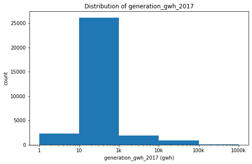

## Distribution of estimated_generation_gwh_2017

estimated_generation_gwh_2017 has arightly-skewed distribution and it is unimodal.

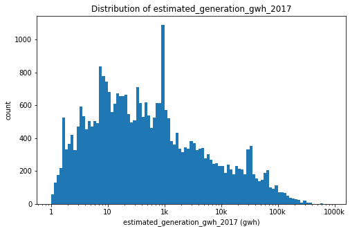

## Distribution of capacity_mw

capacity_mw has a rightly-skewed distribution and it is unimodal.

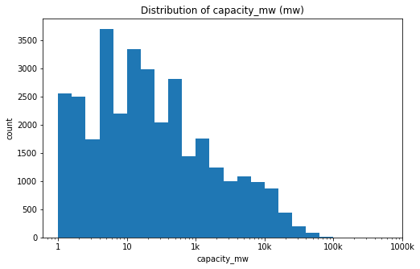

## Relationship between capacity_mw and generation_gwh_2017

There is a positive correlation between both features. Also, there are some of the plots that form a straight line somewhere in the middle of the scatterplot.

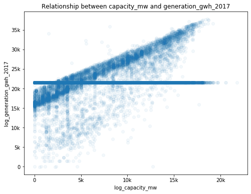

## Relationship between capacity_mw and estimated_generation_gwh_2017

There is a very strong positive correlation between the two features.

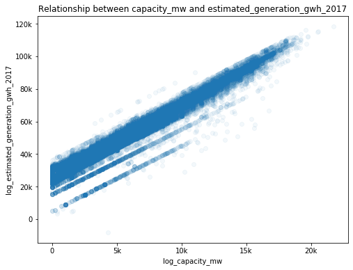

## Distribution of estimated_generation_gwh_2017 by country and primary_fuel

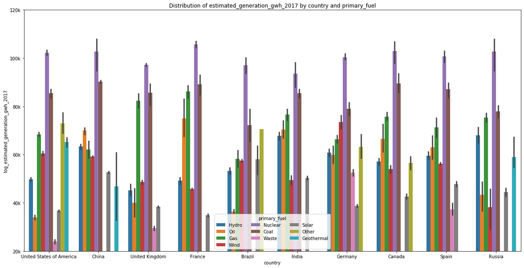